# Vaccines: Many Beliefs Pilot 5

Derek Powell

July 14, 2017

```r
filename <- "vaccBeliefs_diseaseSeverity.csv"
headers <- as.matrix(read.csv(filename, skip = 0, header = F, nrows = 1, as.is = T ))
df <- read.csv(filename, skip = 3, header = F)
colnames(df) <- headers
df <- df[which(df$Status==0),] # remove survey previews
# remove unused qualtrics variables
remove_cols <- c("RecipientLastName",
                 "RecipientFirstName",
                 "RecipientEmail",
                 "Finished",
                 "ResponseId",
                 "ExternalReference",
                 "DistributionChannel",
                 "UserLanguage",
                 "Status")
df <- df[ , -which(names(df) %in% remove_cols)]
df <- df[which(df$diseaseRarity_check_3==3),]
```

```r
all_items <- c("diseaseSevere_1",
"diseaseSevere_2",
"diseaseSevere_3r",
"diseaseSevere_4",
"diseaseSevere_5r",
"diseaseSevere_6",
"diseaseSevere_7",
"diseaseSevere_8r",
"diseaseSevere_9r",
"diseaseSevere_10",
"diseaseSevere_11",
"diseaseSevere_12r",
"diseaseSevere_13r",
"diseaseSevere_14r",
"diseaseSevere_15r",
"diseaseSevere_16r",
"diseaseSevere_17",
"diseaseRarity_1",
"diseaseRarity_2",
"diseaseRarity_3r",
"diseaseRarity_4",
"diseaseRarity_5r",
"vaccIntent_1r",
"vaccIntent_2",
"vaccIntent_3r",
"vaccIntent_4",
"vaccIntent_5r")
```

```r
library(ggplot2)
# df <- read.csv("vb_pilot2.csv")
reverse_items <- all_items[!sapply(
  lapply(all_items, function (x) {
  if (substr(x,nchar(x),nchar(x))=="r") {
    return(x)
  }
}), is.null)]

df[,reverse_items] <- lapply(df[,reverse_items], function(x) {
  8-x
})
df_main <- df[,c("workerId",all_items)]
```

# Introduction

This pilot is specifically targetted at fixing our issues with reliability for disease severity scale.

I’m splitting this data evenly into training and validation sets. The plan is to pick several candidate scales based on the “training” data and then ensure it remains reliable when tested on the validation set.

```r
library(dplyr)
train <- df_main %>% sample_frac(.5)
test  <- dplyr::anti_join(df_main, train, by = 'workerId')
# train <- train[, all_items]
```

## Disease Severity

Here’s a correlation plot of all items sorted by hierarchical clustering.

Looks like 2,4,7 are closely tied together. ALso, 15r, 8r, 16r and 17, 1, 11

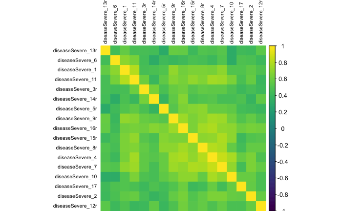

```r
diseaseSevere <- all_items[1:17]
# diseaseSevere <-
# diseaseSevere.alpha <- psych::alpha(df[,diseaseSevere])
# diseaseSevere.alpha$total$raw_alpha
# diseaseSevere.alpha \
corrplot(cor(train[,diseaseSevere]),
         order="hclust",
         # addrect=3,
         tl.cex=.65,
         tl.col="black",
         method="color",
         col=viridis(128))
```

## proposed scales

1. Items 2, 4, 7, 8r, 16r.
2. Items 1, 4, 7, 8r, 3r.
3. Items 4, 8r, 16r, 15r, 11
4. Items 3r, 4, 7, 8r, 11
5. Items 1, 3r, 4, 9r, 11, 17 (6 items)

### Scale 1

1. Whooping cough often makes you sick for months.
2. Childhood diseases are serious diseases.
3. Diseases like measles, mumps, and whooping cough can cause permanent damage to a child who contracts them.
4. Childhood diseases are not that big a deal.*
5. Measles, mumps, and whooping cough are mild enough that they don’t really deserve to be called “diseases.”*

```r
s1 <- all_items[c(2,4,7,8,16)]
s1.alpha <- psych::alpha(train[,s1])
s1.alpha$total$raw_alpha
```

```
[1] 0.9260544
```

```r
s1.alpha
```

```
Reliability analysis
Call: psych::alpha(x = train[, s1])

  raw_alpha std.alpha G6(smc) average_r S/N   ase mean  sd
      0.93      0.93    0.92      0.72  13 0.016  5.6 1.2

 lower alpha upper     95% confidence boundaries
0.89 0.93 0.96

 Reliability if an item is dropped:
                  raw_alpha std.alpha G6(smc) average_r  S/N alpha se
diseaseSevere_2        0.93      0.93    0.92      0.78 14.3    0.014
diseaseSevere_4        0.89      0.90    0.88      0.68  8.6    0.024
diseaseSevere_7        0.90      0.90    0.88      0.70  9.2    0.022
diseaseSevere_8r       0.91      0.91    0.89      0.71 10.0    0.020
diseaseSevere_16r      0.91      0.91    0.89      0.72 10.0    0.021

 Item statistics
                   n raw.r std.r r.cor r.drop mean  sd
diseaseSevere_2   56  0.80  0.79  0.71   0.68  4.9 1.5
diseaseSevere_4   56  0.93  0.93  0.92   0.88  5.7 1.4
diseaseSevere_7   56  0.91  0.91  0.89   0.85  5.5 1.4
diseaseSevere_8r  56  0.88  0.89  0.86   0.82  6.0 1.3
diseaseSevere_16r 56  0.88  0.88  0.85   0.82  5.8 1.3

Non missing response frequency for each item
                     2    3    4    5    6    7 miss
diseaseSevere_2   0.04 0.18 0.21 0.20 0.21 0.16    0
diseaseSevere_4   0.04 0.09 0.04 0.23 0.23 0.38    0
diseaseSevere_7   0.02 0.09 0.09 0.27 0.21 0.32    0
diseaseSevere_8r  0.02 0.05 0.07 0.12 0.25 0.48    0
diseaseSevere_16r 0.02 0.05 0.09 0.18 0.27 0.39    0
```

### Scale 2

1. Measles can be life-threatening.
2. Childhood diseases are serious diseases.
3. Diseases like measles, mumps, and whooping cough can cause permanent damage to a child who contracts them.
4. Childhood diseases are not that big a deal.*
5. Measles, mumps, and whooping cough are no more severe than the flu.*

```r
s2 <- all_items[c(1,4,7,8,3)]
s2.alpha <- psych::alpha(train[,s2])
s2.alpha$total$raw_alpha
```

```
[1] 0.9023728
```

```r
s2.alpha
```

```
Reliability analysis
Call: psych::alpha(x = train[, s2])

  raw_alpha std.alpha G6(smc) average_r S/N   ase mean  sd
       0.9       0.9     0.9      0.66 9.5 0.021  5.7 1.2

 lower alpha upper     95% confidence boundaries
0.86 0.9 0.94

 Reliability if an item is dropped:
                 raw_alpha std.alpha G6(smc) average_r  S/N alpha se
diseaseSevere_1       0.89      0.90    0.88      0.68  8.6    0.024
diseaseSevere_4       0.86      0.87    0.84      0.62  6.5    0.031
diseaseSevere_7       0.86      0.86    0.84      0.61  6.3    0.031
diseaseSevere_8r      0.87      0.87    0.86      0.63  6.7    0.030
diseaseSevere_3r      0.92      0.92    0.90      0.74 11.1    0.018

 Item statistics
                  n raw.r std.r r.cor r.drop mean  sd
diseaseSevere_1  56  0.80  0.81  0.74   0.70  5.7 1.3
diseaseSevere_4  56  0.90  0.90  0.90   0.84  5.7 1.4
diseaseSevere_7  56  0.91  0.91  0.91   0.85  5.5 1.4
diseaseSevere_8r 56  0.89  0.89  0.87   0.82  6.0 1.3
diseaseSevere_3r 56  0.75  0.74  0.62   0.60  5.6 1.5

Non missing response frequency for each item
                    1    2    3    4    5    6    7 miss
diseaseSevere_1  0.00 0.02 0.05 0.09 0.27 0.23 0.34    0
diseaseSevere_4  0.00 0.04 0.09 0.04 0.23 0.23 0.38    0
diseaseSevere_7  0.00 0.02 0.09 0.09 0.27 0.21 0.32    0
diseaseSevere_8r 0.00 0.02 0.05 0.07 0.12 0.25 0.48    0
diseaseSevere_3r 0.02 0.02 0.09 0.11 0.05 0.39 0.32    0
```

### Scale 3

```r
s3 <- all_items[c(4,8,16,15,11)]
s3.alpha <- psych::alpha(train[,s3])
s3.alpha$total$raw_alpha
```

```
[1] 0.9256026
```

```r
s3.alpha
```

```
Reliability analysis
Call: psych::alpha(x = train[, s3])

  raw_alpha std.alpha G6(smc) average_r S/N   ase mean  sd
      0.93      0.93    0.92      0.72  13 0.015  5.8 1.1

 lower alpha upper     95% confidence boundaries
0.9 0.93 0.96

 Reliability if an item is dropped:
                  raw_alpha std.alpha G6(smc) average_r  S/N alpha se
diseaseSevere_4        0.90      0.90    0.87      0.69  8.7    0.023
diseaseSevere_8r       0.90      0.91    0.89      0.71  9.6    0.020
diseaseSevere_16r      0.91      0.91    0.89      0.72 10.5    0.019
diseaseSevere_15r      0.92      0.92    0.90      0.73 11.0    0.018
diseaseSevere_11       0.92      0.92    0.90      0.73 11.0    0.018

 Item statistics
                   n raw.r std.r r.cor r.drop mean  sd
diseaseSevere_4   56  0.93  0.92  0.91   0.87  5.7 1.4
diseaseSevere_8r  56  0.90  0.89  0.86   0.83  6.0 1.3
diseaseSevere_16r 56  0.87  0.87  0.83   0.80  5.8 1.3
diseaseSevere_15r 56  0.84  0.86  0.80   0.77  5.9 1.1
diseaseSevere_11  56  0.85  0.86  0.81   0.77  5.7 1.2

Non missing response frequency for each item
                     2    3    4    5    6    7 miss
diseaseSevere_4   0.04 0.09 0.04 0.23 0.23 0.38    0
diseaseSevere_8r  0.02 0.05 0.07 0.12 0.25 0.48    0
diseaseSevere_16r 0.02 0.05 0.09 0.18 0.27 0.39    0
diseaseSevere_15r 0.00 0.04 0.07 0.20 0.32 0.38    0
diseaseSevere_11  0.00 0.04 0.14 0.27 0.23 0.32    0
```

### Scale 4

1. Measles, mumps, and whooping cough are no more severe than the flu.*
2. Childhood diseases are serious diseases.
3. Diseases like measles, mumps, and whooping cough can cause permanent damage to a child who contracts them.
4. Childhood diseases are not that big a deal.*
5. Diseases like measles and whooping cough are extremely dangerous for young children.

```r
s4 <- all_items[c(3,4,7,8,11)]
s4.alpha <- psych::alpha(train[,s4])
s4.alpha$total$raw_alpha
```

```
[1] 0.9127911
```

```r
s4.alpha
```

```
Reliability analysis
Call: psych::alpha(x = train[, s4])

  raw_alpha std.alpha G6(smc) average_r S/N   ase mean  sd
      0.91      0.92    0.91      0.69  11 0.019  5.7 1.2

 lower alpha upper     95% confidence boundaries
0.88 0.91 0.95

 Reliability if an item is dropped:
                 raw_alpha std.alpha G6(smc) average_r  S/N alpha se
diseaseSevere_3r      0.93      0.93    0.91      0.77 13.1    0.015
diseaseSevere_4       0.88      0.88    0.86      0.65  7.4    0.028
diseaseSevere_7       0.88      0.88    0.87      0.66  7.6    0.027
diseaseSevere_8r      0.89      0.89    0.88      0.68  8.4    0.025
diseaseSevere_11      0.89      0.90    0.88      0.68  8.6    0.024

 Item statistics
                  n raw.r std.r r.cor r.drop mean  sd
diseaseSevere_3r 56  0.77  0.76  0.65   0.62  5.6 1.5
diseaseSevere_4  56  0.91  0.92  0.91   0.86  5.7 1.4
diseaseSevere_7  56  0.91  0.91  0.90   0.85  5.5 1.4
diseaseSevere_8r 56  0.88  0.88  0.84   0.81  6.0 1.3
diseaseSevere_11 56  0.86  0.87  0.83   0.79  5.7 1.2

Non missing response frequency for each item
                    1    2    3    4    5    6    7 miss
diseaseSevere_3r 0.02 0.02 0.09 0.11 0.05 0.39 0.32    0
diseaseSevere_4  0.00 0.04 0.09 0.04 0.23 0.23 0.38    0
diseaseSevere_7  0.00 0.02 0.09 0.09 0.27 0.21 0.32    0
diseaseSevere_8r 0.00 0.02 0.05 0.07 0.12 0.25 0.48    0
diseaseSevere_11 0.00 0.00 0.04 0.14 0.27 0.23 0.32    0
```

### Scale 5

1. Measles can be life-threatening.
2. Measles, mumps, and whooping cough are no more severe than the flu.*
3. Childhood diseases are serious diseases.
4. A child getting measles might be a hassle, but it would not be a cause for serious concern.*
5. Diseases like measles and whooping cough are extremely dangerous for young children.
6. Measles and whooping cough can be just as deadly as Polio.

```r
s5 <- all_items[c(1, 3, 4, 9, 11, 17)]
s5.alpha <- psych::alpha(train[,s5])
s5.alpha$total$raw_alpha
```

```
[1] 0.8945167
```

```r
s5.alpha
```

```
Reliability analysis
Call: psych::alpha(x = train[, s5])

  raw_alpha std.alpha G6(smc) average_r S/N   ase mean  sd
      0.89       0.9    0.91       0.6 9.1 0.022  5.5 1.2

 lower alpha upper     95% confidence boundaries
0.85 0.89 0.94

 Reliability if an item is dropped:
                 raw_alpha std.alpha G6(smc) average_r S/N alpha se
diseaseSevere_1       0.87      0.88    0.87      0.59 7.2    0.027
diseaseSevere_3r      0.89      0.90    0.90      0.64 8.9    0.023
diseaseSevere_4       0.86      0.87    0.87      0.57 6.7    0.030
diseaseSevere_9r      0.86      0.87    0.87      0.58 6.9    0.029
diseaseSevere_11      0.87      0.87    0.86      0.57 6.7    0.028
diseaseSevere_17      0.90      0.90    0.91      0.65 9.5    0.021

 Item statistics
                  n raw.r std.r r.cor r.drop mean  sd
diseaseSevere_1  56  0.83  0.84  0.82   0.75  5.7 1.3
diseaseSevere_3r 56  0.74  0.74  0.65   0.62  5.6 1.5
diseaseSevere_4  56  0.88  0.88  0.86   0.81  5.7 1.4
diseaseSevere_9r 56  0.87  0.87  0.84   0.79  5.4 1.5
diseaseSevere_11 56  0.86  0.88  0.87   0.81  5.7 1.2
diseaseSevere_17 56  0.73  0.71  0.61   0.58  4.8 1.6

Non missing response frequency for each item
                    1    2    3    4    5    6    7 miss
diseaseSevere_1  0.00 0.02 0.05 0.09 0.27 0.23 0.34    0
diseaseSevere_3r 0.02 0.02 0.09 0.11 0.05 0.39 0.32    0
diseaseSevere_4  0.00 0.04 0.09 0.04 0.23 0.23 0.38    0
diseaseSevere_9r 0.02 0.00 0.14 0.12 0.11 0.32 0.29    0
diseaseSevere_11 0.00 0.00 0.04 0.14 0.27 0.23 0.32    0
diseaseSevere_17 0.02 0.07 0.16 0.14 0.23 0.21 0.16    0
```

# Validation

Now we’ll test all 5 on the validation set and see how great the loss of reliability is.

```r
s1 <- all_items[c(2,4,7,8,16)]
s1.alpha <- psych::alpha(test[,s1])
s1.alpha$total$raw_alpha
```

```
[1] 0.7963993
```

```r
s1.alpha
```

```
Reliability analysis
Call: psych::alpha(x = test[, s1])

  raw_alpha std.alpha G6(smc) average_r S/N   ase mean   sd
       0.8       0.8    0.82      0.45 4.1 0.043  5.7 0.96

 lower alpha upper     95% confidence boundaries
0.71 0.8 0.88

 Reliability if an item is dropped:
                  raw_alpha std.alpha G6(smc) average_r S/N alpha se
diseaseSevere_2        0.81      0.82    0.80      0.53 4.6    0.040
diseaseSevere_4        0.71      0.71    0.73      0.38 2.5    0.062
diseaseSevere_7        0.72      0.72    0.74      0.40 2.6    0.060
diseaseSevere_8r       0.75      0.77    0.76      0.45 3.3    0.055
diseaseSevere_16r      0.78      0.79    0.78      0.48 3.7    0.050

 Item statistics
                   n raw.r std.r r.cor r.drop mean  sd
diseaseSevere_2   57  0.58  0.61  0.49   0.37  5.0 1.2
diseaseSevere_4   57  0.84  0.85  0.82   0.74  6.0 1.1
diseaseSevere_7   57  0.82  0.83  0.79   0.70  5.8 1.2
diseaseSevere_8r  57  0.77  0.74  0.67   0.59  5.8 1.4
diseaseSevere_16r 57  0.74  0.70  0.61   0.54  5.6 1.5

Non missing response frequency for each item
                     1    2    3    4    5    6    7 miss
diseaseSevere_2   0.00 0.02 0.02 0.39 0.23 0.21 0.14    0
diseaseSevere_4   0.00 0.00 0.05 0.07 0.12 0.37 0.39    0
diseaseSevere_7   0.00 0.00 0.05 0.11 0.19 0.26 0.39    0
diseaseSevere_8r  0.02 0.02 0.04 0.11 0.14 0.23 0.46    0
diseaseSevere_16r 0.00 0.05 0.07 0.09 0.11 0.33 0.35    0
```

```r
s2 <- all_items[c(1,4,7,8,3)]
s2.alpha <- psych::alpha(test[,s2])
s2.alpha$total$raw_alpha
```

```
[1] 0.8304767
```

```r
# s2.alpha
```

```r
s3 <- all_items[c(4,8,16,15,11)]
s3.alpha <- psych::alpha(test[,s3])
s3.alpha$total$raw_alpha
```

```
[1] 0.8568959
```

```r
s3.alpha
```

```
Reliability analysis
Call: psych::alpha(x = test[, s3])

  raw_alpha std.alpha G6(smc) average_r S/N   ase mean  sd
      0.86      0.86    0.86      0.54 5.9 0.029  5.8 1.1

 lower alpha upper     95% confidence boundaries
0.8 0.86 0.91

 Reliability if an item is dropped:
                  raw_alpha std.alpha G6(smc) average_r S/N alpha se
diseaseSevere_4        0.85      0.84    0.83      0.58 5.4    0.032
diseaseSevere_8r       0.80      0.80    0.77      0.50 3.9    0.043
diseaseSevere_16r      0.82      0.82    0.83      0.53 4.6    0.038
diseaseSevere_15r      0.81      0.81    0.78      0.52 4.4    0.040
diseaseSevere_11       0.85      0.85    0.85      0.58 5.6    0.031

 Item statistics
                   n raw.r std.r r.cor r.drop mean  sd
diseaseSevere_4   57  0.72  0.75  0.66   0.59  6.0 1.1
diseaseSevere_8r  57  0.87  0.87  0.86   0.78  5.8 1.4
diseaseSevere_16r 57  0.82  0.81  0.74   0.70  5.6 1.5
diseaseSevere_15r 57  0.85  0.83  0.82   0.74  5.7 1.5
diseaseSevere_11  57  0.71  0.73  0.62   0.57  5.7 1.2

Non missing response frequency for each item
                     1    2    3    4    5    6    7 miss
diseaseSevere_4   0.00 0.00 0.05 0.07 0.12 0.37 0.39    0
diseaseSevere_8r  0.02 0.02 0.04 0.11 0.14 0.23 0.46    0
diseaseSevere_16r 0.00 0.05 0.07 0.09 0.11 0.33 0.35    0
diseaseSevere_15r 0.02 0.02 0.07 0.09 0.16 0.28 0.37    0
diseaseSevere_11  0.00 0.02 0.02 0.14 0.25 0.23 0.35    0
```

```r
s4 <- all_items[c(3,4,7,8,11)]
s4.alpha <- psych::alpha(test[,s4])
s4.alpha$total$raw_alpha
```

```
[1] 0.8394905
```

```r
s4.alpha
```

```
Reliability analysis
Call: psych::alpha(x = test[, s4])

  raw_alpha std.alpha G6(smc) average_r S/N   ase mean sd
      0.84      0.85    0.85      0.53 5.6 0.034  5.7  1

 lower alpha upper     95% confidence boundaries
0.77 0.84 0.91

 Reliability if an item is dropped:
                 raw_alpha std.alpha G6(smc) average_r S/N alpha se
diseaseSevere_3r      0.84      0.84    0.83      0.58 5.4    0.036
diseaseSevere_4       0.80      0.81    0.79      0.51 4.2    0.044
diseaseSevere_7       0.79      0.79    0.76      0.49 3.8    0.046
diseaseSevere_8r      0.81      0.83    0.80      0.54 4.8    0.041
diseaseSevere_11      0.80      0.81    0.79      0.51 4.2    0.044

 Item statistics
                  n raw.r std.r r.cor r.drop mean  sd
diseaseSevere_3r 57  0.74  0.71  0.60   0.56  5.3 1.5
diseaseSevere_4  57  0.79  0.81  0.76   0.68  6.0 1.1
diseaseSevere_7  57  0.83  0.84  0.83   0.72  5.8 1.2
diseaseSevere_8r 57  0.78  0.76  0.68   0.62  5.8 1.4
diseaseSevere_11 57  0.80  0.81  0.77   0.68  5.7 1.2

Non missing response frequency for each item
                    1    2    3    4    5    6    7 miss
diseaseSevere_3r 0.04 0.02 0.05 0.14 0.21 0.32 0.23    0
diseaseSevere_4  0.00 0.00 0.05 0.07 0.12 0.37 0.39    0
diseaseSevere_7  0.00 0.00 0.05 0.11 0.19 0.26 0.39    0
diseaseSevere_8r 0.02 0.02 0.04 0.11 0.14 0.23 0.46    0
diseaseSevere_11 0.00 0.02 0.02 0.14 0.25 0.23 0.35    0
```

```r
s5 <- all_items[c(1, 3, 4, 9, 11, 17)]
s5.alpha <- psych::alpha(test[,s5])
s5.alpha$total$raw_alpha
```

```
[1] 0.8286059
```

```r
s5.alpha
```

```
Reliability analysis
Call: psych::alpha(x = test[, s5])

  raw_alpha std.alpha G6(smc) average_r S/N   ase mean sd
      0.83      0.84    0.86      0.47 5.2 0.037  5.5  1

 lower alpha upper     95% confidence boundaries
0.76 0.83 0.9

 Reliability if an item is dropped:
                 raw_alpha std.alpha G6(smc) average_r S/N alpha se
diseaseSevere_1       0.78      0.79    0.81      0.43 3.8    0.048
diseaseSevere_3r      0.81      0.83    0.84      0.49 4.8    0.041
diseaseSevere_4       0.81      0.82    0.85      0.48 4.5    0.043
diseaseSevere_9r      0.83      0.84    0.85      0.51 5.2    0.036
diseaseSevere_11      0.77      0.78    0.81      0.42 3.6    0.049
diseaseSevere_17      0.81      0.82    0.81      0.47 4.4    0.041

 Item statistics
                  n raw.r std.r r.cor r.drop mean  sd
diseaseSevere_1  57  0.82  0.83  0.81   0.73  5.5 1.3
diseaseSevere_3r 57  0.71  0.69  0.61   0.55  5.3 1.5
diseaseSevere_4  57  0.70  0.72  0.63   0.58  6.0 1.1
diseaseSevere_9r 57  0.67  0.64  0.55   0.48  5.2 1.6
diseaseSevere_11 57  0.84  0.85  0.84   0.76  5.7 1.2
diseaseSevere_17 57  0.73  0.74  0.71   0.57  5.0 1.5

Non missing response frequency for each item
                    1    2    3    4    5    6    7 miss
diseaseSevere_1  0.00 0.00 0.04 0.25 0.21 0.21 0.30    0
diseaseSevere_3r 0.04 0.02 0.05 0.14 0.21 0.32 0.23    0
diseaseSevere_4  0.00 0.00 0.05 0.07 0.12 0.37 0.39    0
diseaseSevere_9r 0.02 0.05 0.11 0.09 0.28 0.16 0.30    0
diseaseSevere_11 0.00 0.02 0.02 0.14 0.25 0.23 0.35    0
diseaseSevere_17 0.00 0.05 0.12 0.23 0.18 0.19 0.23    0
```

## Result

All are acceptably reliable! Scale 3 has the highest reliability at validation (and 95% confidence intervals don’t go below .80), but I think we can feel reasonably safe picking from among these scales (and possibly recombining items).